# Лекция 11. Регрессия разрывов

Блок 3. Естественные эксперименты и отбор по ненаблюдаемым

Карен Аванесян

Каузальный анализ в R на данных RLMS-HSE

# Зачем

## Порог как эксперимент

- Многие правила включаются по **порогу**: пенсия с 55 лет, льгота при доходе ниже $X$, зачисление по баллу ЕГЭ выше $Y$
- Люди чуть **ниже** и чуть **выше** порога почти одинаковы — но одни получают воздействие, другие нет
- **Регрессия разрывов** (RD): сравниваем исход по обе стороны порога, экстраполируя гладкие тренды к самому порогу

RD — самый убедительный квазиэксперимент после рандомизации: допущение (гладкость всего, кроме воздействия, в точке порога) проверяемо, а идентификация **локальна** — для людей у порога.

## Пример занятия: пенсионный возраст 55

44 428 наблюдений: женщины 45–64 лет, 2000–2018 (до реформы)

55 порог: пенсия по возрасту у женщин до 2019 г.

60 порог у мужчин

0.5 года шаг возраста в RLMS: по обе стороны 55 есть люди 54.5 и 55

дизайн

### Бегущая переменная — возраст

Порог — 55. Сравниваем женщин чуть младше и чуть старше порога.

вопросы

### Что происходит в 55 лет

С **получением пенсии** (первая стадия), **занятостью**, **часами**, **здоровьем**, **удовлетворённостью жизнью**

## План занятия

1. Чёткая RD: идея, локальные полиномы, ширина окна
2. `rdplot`, `rdrobust`: оценка и честные интервалы
3. Проверки: плотность, баланс ковариат, плацебо-пороги, чувствительность к $h$
4. Как читать вывод `rdrobust()` и `rddensity()` и писать результат
5. Нечёткая RD: когда порог меняет не всё — мост к IV
6. Особенности возраста как бегущей переменной

# Идея

## Чёткая RD

Бегущая переменная $X$, порог $c$, воздействие $D = \mathbb{1}[X \ge c]$. Эффект на пороге:

$$\tau_{RD} = \lim_{x \downarrow c} E[Y \mid X = x] - \lim_{x \uparrow c} E[Y \mid X = x]$$

- Допущение: $E[Y(0) \mid X]$ и $E[Y(1) \mid X]$ **непрерывны** в $c$ — в точке порога меняется только $D$
- Два предела оцениваются **локальной линейной регрессией** в окне $[c - h, c + h]$ с треугольными весами
- Выбор $h$ — компромисс смещение/дисперсия: `rdbwselect` подбирает оптимальную, `rdrobust` корректирует смещение и даёт **робастные** интервалы (CCT 2014). Высокие полиномы на всём диапазоне — плохая практика (Gelman & Imbens 2019)

## Что проверять

| Проверка | Инструмент | Что должно быть |
| --- | --- | --- |
| Манипуляция бегущей переменной | тест плотности `rddensity` | нет скачка плотности в $c$ |
| Баланс ковариат | RD с ковариатой как исходом | нет скачков в образовании, браке, поселении |
| Плацебо-пороги | RD в $c' \ne c$ | нет эффекта |
| Чувствительность к окну | оценки при разных $h$ | стабильны |
| «Пончик» (donut) | убрать наблюдения вплотную к порогу | оценка не меняется |
| Другие правила на том же пороге | знание институтов | нет совпадающих порогов |

## Нечёткая RD

Если на пороге воздействие получают **не все** (кто-то вышел на пенсию раньше, кто-то позже), скачок в $D$ меньше единицы:

$$\tau_{fuzzy} = \frac{\text{скачок в } Y}{\text{скачок в } D}$$

- Это **инструментальная переменная**: индикатор «выше порога» — инструмент для $D$. Эстиманд — эффект для **комплаеров** на пороге (LATE)
- Нужны те же допущения, что в IV (лекция 12): порог влияет на $Y$ только через $D$
- `rdrobust(y, x, c, fuzzy = d)` делает всё за одну строку

# Код

## Картинка прежде всего: `rdplot`

```r
rdplot(w$pension, w$age_exact, c = 55, p = 1, x.label = "возраст", y.label = "доля получающих пенсию",
       title = "", col.dots = pal["indigo"], col.lines = pal["coral"])
```

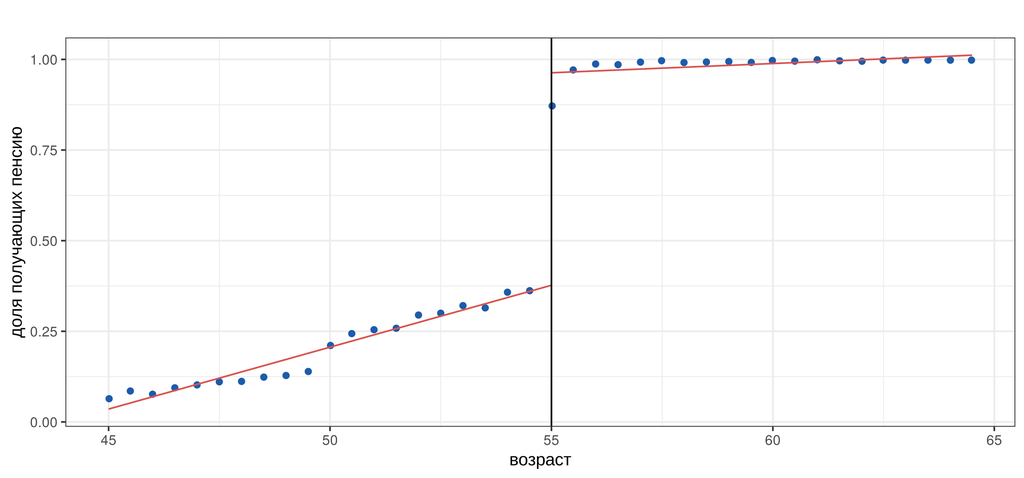

## Первая стадия: пенсия

```r
r_pen <- rd("pension")
```

+0.513 скачок доли получающих пенсию в 55 лет

0.033 стандартная ошибка

1.37 оптимальное окно $h$, лет

5 771 наблюдений в окне (слева + справа)

Полный вывод `summary(r_pen)` разобран на следующем слайде.

## Как читать вывод `rdrobust()`

- Вывод R
- С пояснениями

```
Sharp RD estimates using local polynomial regression.
Number of Obs.                44428
BW type                       mserd
Kernel                   Triangular
VCE method                       NN
                               Left        Right
Number of Obs.                23231        21197
Eff. Number of Obs.            2328         3443
BW est. (h)                   1.366        1.366
BW bias (b)                   2.720        2.720
Unique Obs.                      20           20
        Method     Coef. Std. Err.         z     P>|z|      [ 95% C.I. ]
  Conventional     0.513     0.033    15.771     0.000     [0.449 , 0.577]
Bias-Corrected     0.509     0.033    15.652     0.000     [0.445 , 0.573]
        Robust     0.509     0.040    12.842     0.000     [0.432 , 0.587]
```

1 · шапка

`Sharp RD`; `mserd` — одно MSE-оптимальное окно по обе стороны; ядро треугольное; `VCE NN` — робастные ошибки по ближайшим соседям (с `cluster =` — кластерные)

2 · Left / Right

`Number of Obs.` — вся выборка, `Eff.` — в окне $h$: 2328 и 3443. Не равны: в окне 2 возраста слева и 3 справа. `Unique Obs.` — число массовых точек

3 · два окна

`BW est. (h)` — окно оценки (линия, $p = 1$), `BW bias (b)` — шире, для оценки смещения параболой ($q = 2$)

4 · Conventional

Точечная оценка: скачок доли на **51 п.п.** в 55 лет. Её «обычная» ошибка не учитывает смещение от кривизны

5 · Bias-Corrected, Robust

Из оценки вычтено смещение; `Robust` добавляет в ошибку неопределённость этой поправки. Сообщаем **Conventional + робастный интервал** (CCT 2014) — `summary()` без `all` печатает именно их

6 · сигналы беды

В окне 1–2 массовые точки с каждой стороны; Conventional значим, Robust — нет; оценка прыгает при соседних $h$

## Занятость, часы, здоровье, удовлетворённость

```r
rdplot(w$employed, w$age_exact, c = 55, p = 1, x.label = "возраст", y.label = "доля занятых",
       title = "", col.dots = pal["indigo"], col.lines = pal["coral"])
```

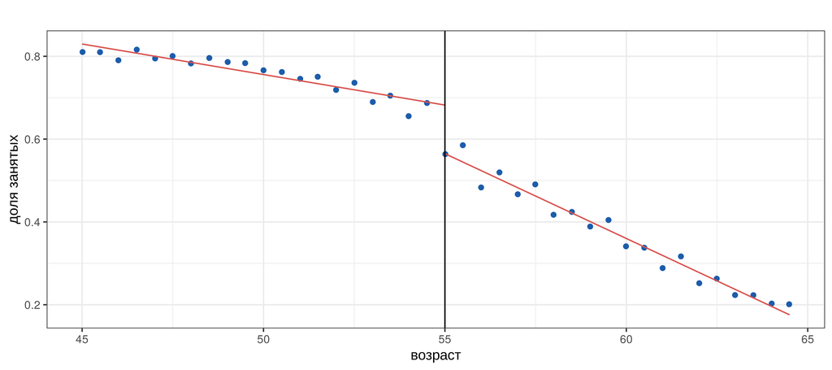

## Все исходы в одной таблице

```r
bind_rows(rd_row("pension", "получает пенсию"), rd_row("employed", "занята"),
          rd_row("hours_week", "часов в неделю (занятые)"),
          rd_row("log_wage", "log зарплаты (занятые)"),
          rd_row("health_score", "здоровье 1–5"),
          rd_row("life_sat", "удовлетворённость жизнью 1–5")) |>
  mutate(across(c(оценка, se, `робастный p`), ~ round(.x, 3)), h = round(h, 1))
```

| исход | оценка | se | робастный p | h | n слева | n справа |
| --- | --- | --- | --- | --- | --- | --- |
| получает пенсию | 0.513 | 0.033 | 0.000 | 1.4 | 2328 | 3443 |
| занята | -0.095 | 0.020 | 0.000 | 2.6 | 5976 | 6813 |
| часов в неделю (занятые) | 0.205 | 0.763 | 0.582 | 1.8 | 2358 | 2425 |
| log зарплаты (занятые) | -0.010 | 0.042 | 0.751 | 2.4 | 3038 | 2820 |
| здоровье 1–5 | 0.028 | 0.021 | 0.169 | 3.5 | 7037 | 7803 |
| удовлетворённость жизнью 1–5 | 0.013 | 0.054 | 0.863 | 2.1 | 4675 | 5653 |

В 55 лет доля получающих пенсию скачком растёт на 51 п.п., занятость падает на 9–10 п.п. Часы, зарплата оставшихся, здоровье и удовлетворённость жизнью **не меняются**. Окна узкие (1.5–3.5 года): так выбирает `rdbwselect` при массовых точках в возрасте.

## Проверка 1: плотность

```r
dens <- rddensity(w$age_exact, c = 55)
c(`T` = dens$test$t_jk, `p` = dens$test$p_jk) |> round(3)
```

```
     T      p
-0.396  0.692
```

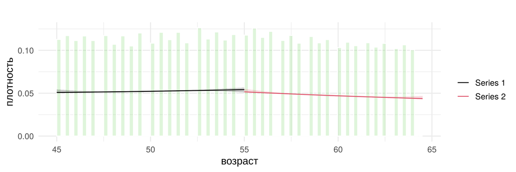

Возраст манипулировать нельзя, и плотность это подтверждает. Но проверка обязательна для любой бегущей переменной, которую люди **могут** двигать: доход, баллы, даты.

## Как читать вывод `rddensity()`

- Вывод R
- С пояснениями

```
Model =               unrestricted
Kernel =              triangular
BW method =           estimated
VCE method =          jackknife
c = 55                Left of c           Right of c
Number of obs         23231               21197
Eff. Number of obs    23231               21197
BW est. (h)           10                  10
Method                T                   P > |T|
Robust                -0.3959             0.6922
P-values of binomial tests (H0: p=0.5).
Window Length / 2          <c     >=c    P>|T|
0.500                    1196    2338    0.0000
1.000                    2328    3443    0.0000
1.500                    3555    4615    0.0000
```

1 · шапка

`unrestricted` — плотности слева и справа оцениваются отдельно (локальные параболы); ошибки — jackknife

2 · окно

`BW est. (h)` = 10: окно шире данных (45–64 года), поэтому `Eff.` = все наблюдения. Пакет предупреждает об этом и о повторах значений

3 · `Robust`

Главная строка. H0: плотность непрерывна в $c$. T = -0.4, p = 0.69 — скачка нет

4 · биномиальные тесты

Доли наблюдений слева и справа в узких окнах. p ≈ 0 — артефакт шага 0.5: в окне ±0.5 одна точка слева (54.5) и две справа (55, 55.5)

5 · что сообщать

T и p из строки `Robust` и график плотности. Биномиальные тесты — только для непрерывной бегущей переменной

6 · сигналы беды

p < 0.05 при переменной, которую люди могут двигать (доход, балл); «ямка» перед порогом и «горб» за ним

## Проверка 2: баланс ковариат на пороге

```r
bind_rows(rd_row("higher_ed", "высшее образование"), rd_row("married", "в браке"),
          rd_row("urban", "город"), rd_row("n_children", "число детей")) |>
  mutate(across(c(оценка, se, `робастный p`), ~ round(.x, 3)), h = round(h, 1))
```

| исход | оценка | se | робастный p | h | n слева | n справа |
| --- | --- | --- | --- | --- | --- | --- |
| высшее образование | 0.002 | 0.014 | 0.999 | 3.9 | 8289 | 8956 |
| в браке | -0.002 | 0.016 | 0.921 | 3.9 | 8298 | 8968 |
| город | -0.001 | 0.016 | 0.927 | 3.9 | 8298 | 8968 |
| число детей | -0.011 | 0.038 | 0.813 | 3.4 | 6078 | 7066 |

- Образование, брак, поселение, дети — всё гладко в 55. Разрыв в занятости не объясняется составом
- Ковариаты можно и включить в оценку (`covs =`) — для точности, не для идентификации

## Проверка 3: плацебо-пороги

- Результат
- Код

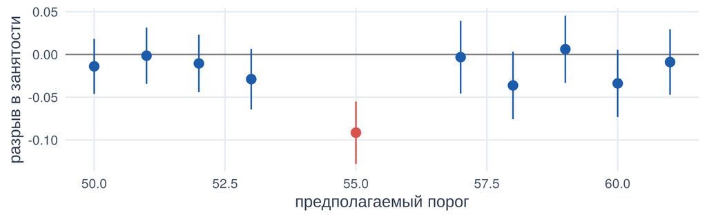

```r
side <- function(c) {                                   # плацебо — по одну сторону от 55
  if (c < 55) filter(w, age_exact < 55) else if (c > 55) filter(w, age_exact >= 55) else w }
placebo <- map_dfr(c(50, 51, 52, 53, 55, 57, 58, 59, 60, 61),
                   ~ rd_row("employed", d = side(.x), c = .x, h = 3) |> mutate(порог = .x))
ggplot(placebo, aes(порог, оценка)) +
  geom_hline(yintercept = 0, colour = "grey50") +
  geom_pointrange(aes(ymin = оценка - 1.96 * se, ymax = оценка + 1.96 * se),
                  colour = ifelse(placebo$порог == 55, pal["coral"], pal["indigo"])) +
  labs(x = "предполагаемый порог", y = "разрыв в занятости")
```

## Проверка 4: чувствительность к окну

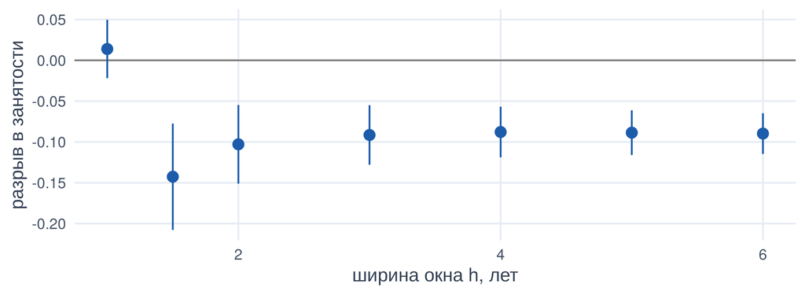

```r
bw <- map_dfr(c(1, 1.5, 2, 3, 4, 5, 6), ~ rd_row("employed", h = .x) |> mutate(h = .x))
ggplot(bw, aes(h, оценка)) +
  geom_hline(yintercept = 0, colour = "grey50") +
  geom_pointrange(aes(ymin = оценка - 1.96 * se, ymax = оценка + 1.96 * se), colour = pal["indigo"]) +
  labs(x = "ширина окна h, лет", y = "разрыв в занятости")
```

При $h \ge 1.5$ оценка устойчива: −9…−14 п.п. При $h = 1$ с каждой стороны остаются две массовые точки — линия через две точки, оценка ненадёжна.

## Как писать результат: чёткая RD

шаблон

«В 55 лет — возраст выхода на пенсию женщин до 2019 г. — доля занятых скачком снижается на **9.5 п.п.** (локально линейная RD, треугольное ядро, MSE-оптимальное окно $h$ = 2.6 года; 5 976 и 6 813 наблюдений слева и справа; робастный 95 % ДИ [-15; -5.3] п.п.). Плотность возраста у порога непрерывна (p = 0.69), ковариаты сбалансированы, оценка устойчива к выбору окна при $h \ge 1.5$.»

- Назвать estimand: эффект **достижения порога** (права на пенсию) у женщин около 55 лет — ещё не эффект самой пенсии
- Обязательно: Conventional-оценка с **робастным** интервалом, $h$, ядро, эффективное N; оговорка о шаге 0.5 года

## Нечёткая RD: эффект пенсии, а не возраста

Порог 55 переводит на пенсию не всех (у части она уже есть с 50, кто-то оформит позже). Эффект **получения пенсии** на занятость:

```r
r_fuzzy <- rd("employed", fuzzy = w$pension[!is.na(w$employed)])
tibble(`чёткая RD (эффект порога)` = rd("employed")$coef[1],
       `скачок в получении пенсии` = r_pen$coef[1],
       `нечёткая RD (эффект пенсии)` = r_fuzzy$coef[1], se = r_fuzzy$se[1]) |> round(3)
```

| чёткая RD (эффект порога) | скачок в получении пенсии | нечёткая RD (эффект пенсии) | se |
| --- | --- | --- | --- |
| -0.095 | 0.513 | -0.168 | 0.031 |

- Нечёткая RD делит скачки в **одном** окне $h$ = 3.47: -0.09 / 0.535 = -0.168. Среди тех, кого порог **перевёл** на пенсию, занятость падает на 17 п.п.
- Это LATE для комплаеров на пороге. Та же арифметика Вальда, что в лекции 12

## Нечёткая RD: первая стадия на картинке

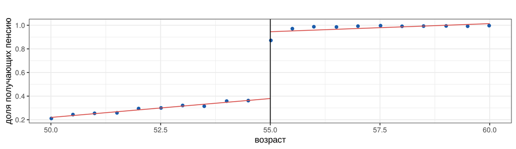

0.38 доля с пенсией чуть **до** 55: досрочные пенсии

0.91 доля чуть **после** 55: не все оформляют сразу

+0.535 скачок = доля комплаеров (первая стадия)

## Как читать вывод `rdrobust(..., fuzzy = )`

- Вывод R
- С пояснениями

```
Fuzzy RD estimates using local polynomial regression.
BW type                       mserd
                               Left        Right
Eff. Number of Obs.            7075         7853
BW est. (h)                   3.470        3.470
BW bias (b)                   5.639        5.639
First-stage estimates.
        Method     Coef. Std. Err.         z     P>|z|      [ 95% C.I. ]
  Conventional     0.535     0.015    35.173     0.000     [0.505 , 0.564]
Bias-Corrected     0.527     0.015    34.675     0.000     [0.497 , 0.557]
        Robust     0.527     0.019    28.041     0.000     [0.490 , 0.564]
Treatment effect estimates.
        Method     Coef. Std. Err.         z     P>|z|      [ 95% C.I. ]
  Conventional    -0.168     0.031    -5.349     0.000    [-0.229 , -0.106]
Bias-Corrected    -0.170     0.031    -5.435     0.000    [-0.232 , -0.109]
        Robust    -0.170     0.038    -4.530     0.000    [-0.244 , -0.097]
```

1 · шапка

`Fuzzy RD`; одно окно $h$ = 3.47 для обеих стадий, выбранное для **отношения** — поэтому шире, чем в чёткой RD для пенсии (1.37)

2 · First-stage

Скачок доли получающих пенсию: 0.535, z = 35 (в терминах IV: F ≈ z² ≈ 1 237). Инструмент сильный

3 · Treatment effect

-0.168 = скачок занятости / скачок пенсии. **LATE** для комплаеров у порога: тех, кто оформляет пенсию именно в 55

4 · строки

Как в чёткой RD: точка — `Conventional`, интервал — `Robust`: [-0.244; -0.097]

5 · это IV

Та же оценка — 2SLS в окне $\pm h$ с треугольными весами: `employed ~ x + x:above | pension ~ above` (следующий слайд, лекция 12)

6 · сигналы беды

Первая стадия с z < 3–4: отношение «взрывается»; знак первой стадии против правила; нечёткую оценку сравнивают с чёткой, не деля на первую стадию

## Нечёткая RD = IV в окне

```r
x_f <- w |> filter(!is.na(employed), abs(age_exact - 55) <= h_f) |>
  mutate(x = age_exact - 55, above = as.integer(x >= 0), kw = 1 - abs(x) / h_f)   # треугольное ядро
iv_f <- feols(employed ~ x + x:above | pension ~ above, data = x_f, weights = ~kw, vcov = "hetero")
c(`rdrobust, Conventional` = r_fuzzy$coef[1], `2SLS в окне` = coef(iv_f)[["fit_pension"]],
  `Wald первой стадии` = fitstat(iv_f, ~ ivwald)[[1]]$stat) |> round(3)
```

```
rdrobust, Conventional            2SLS в окне     Wald первой стадии
                -0.168                 -0.168               1234.018
```

- Порог — инструмент, «линия слева и справа» — контроли, окно и ядро — веса. Точечные оценки совпадают; интервалы `rdrobust` дополнительно учитывают смещение
- Отсюда и допущения IV (лекция 12): **исключение** — 55 лет влияет на занятость только через пенсию; **монотонность** — порог никого не лишает пенсии

## Как писать результат: нечёткая RD

шаблон

«Среди женщин, которых достижение 55 лет переводит на пенсию (комплаеры у порога), получение пенсии снижает вероятность занятости на **16.8 п.п.** (нечёткая RD, $h$ = 3.5 года; робастный 95 % ДИ [-24.4; -9.7] п.п.). Первая стадия сильная: доля получающих пенсию на пороге растёт с 38 % до 91 % (скачок 53.5 п.п., z = 35).»

- Обязательно: первая стадия (скачок и z/F), что эстиманд — **LATE у порога**, допущение исключения словами (нет ли в 55 лет других льгот и правил)
- Не писать «пенсия снижает занятость на 17 п.п.» без «у комплаеров на пороге»: досрочные пенсионерки и те, кто работает после 55, сюда не входят

## Мужчины: порог 60

```r
m <- rlms |> filter(female == 0, year <= 2018, age_exact >= 50, age_exact < 70, !is.na(pension))
bind_rows(rd_row("pension", "получает пенсию", d = m, c = 60),
          rd_row("employed", "занят", d = m, c = 60),
          rd_row("health_score", "здоровье", d = m, c = 60)) |>
  mutate(across(c(оценка, se, `робастный p`), ~ round(.x, 3)), h = round(h, 1))
```

| исход | оценка | se | робастный p | h | n слева | n справа |
| --- | --- | --- | --- | --- | --- | --- |
| получает пенсию | 0.477 | 0.031 | 0.000 | 1.9 | 2138 | 2632 |
| занят | -0.114 | 0.026 | 0.000 | 2.8 | 3532 | 3841 |
| здоровье | -0.005 | 0.029 | 0.794 | 3.7 | 5023 | 4985 |

Картина та же: пенсия +48 п.п., занятость −11 п.п., здоровье без изменений. Два независимых порога — две реплики одного результата.

## Возраст как бегущая переменная: оговорки

другие правила

### Второй порог там же?

Возраст не манипулируется — но к нему привязаны льготы, северные пенсии в 50, предпенсионный статус. Проверяйте, нет ли второго порога там же

период

### Эффект у порога — в данный период

55-летние 2000–2018 гг. После 2019 г. порог поехал — в лекции 10 это стало DiD

массовые точки

### Шаг 0.5 года

`rdrobust` корректирует ошибки; при годовом шаге — методы для дискретной бегущей переменной (Kolesár & Rothe 2018). «Целые» и «половинные» возрасты в RLMS — разные по составу группы: зигзаг занятости узкие окна ловят как «разрыв» — поэтому плацебо и фиксированное $h$

панель

### Ещё один дизайн

Тот же человек до и после 55 — но это уже event study (лекция 8)

# Как ошибаются

## Шесть ошибок с RD (1/2)

Нажмите на карточку:

ошибка 1

### Глобальный полином

Полином 4-й степени на всём диапазоне вместо локальной линейной регрессии

**Как правильно:** Локальная линейная регрессия в окне $[c - h, c + h]$ с треугольными весами — `rdrobust`

ошибка 2

### Окно «на глаз»

Окно выбрано «на глаз» и не показана чувствительность

**Как правильно:** Оптимальное окно `rdbwselect` / `rdrobust` и оценки при разных $h$

ошибка 3

### Нет теста плотности

Для манипулируемой бегущей переменной (доход, баллы)

**Как правильно:** `rddensity`: нет скачка плотности в $c$

## Шесть ошибок с RD (2/2)

ошибка 4

### Эффект для всех

Эффект на пороге выдаётся за эффект для всех («пенсия снижает занятость на 17 п.п.»)

**Как правильно:** Назвать, для кого эффект: «у порога», «комплаеры» — здесь у 55-летних комплаеров

ошибка 5

### Нечёткая как чёткая

Нечёткую RD оценивают как чёткую: занижают эффект воздействия

**Как правильно:** Нечёткая RD с явной первой стадией: `rdrobust(y, x, c, fuzzy = d)`

ошибка 6

### Второй порог

Не проверили, что на том же пороге не включается что-то ещё

**Как правильно:** Знание институтов: нет совпадающих порогов

## Чек-лист

- `rdplot` с биннами и локальной линейной подгонкой
- `rdrobust`: оценка, робастный интервал, оптимальное окно
- Плотность бегущей переменной (`rddensity`)
- Баланс ковариат на пороге
- Плацебо-пороги и чувствительность к $h$
- Если воздействие не у всех — нечёткая RD с явной первой стадией
- Названо, для кого эффект: «у порога», «комплаеры»

# Мини-задача

## Задание к следующему занятию

1. Оцените разрыв в **доходе** (`income_real`) и в `wealth_ladder` на пороге 55 у женщин. Компенсирует ли пенсия потерю заработка?
2. Постройте RD для **2019–2024 гг.** на пороге 55. Что произошло с первой стадией? Почему RD здесь больше не работает в прежнем виде?
3. Donut-RD: исключите наблюдения в ±0.5 года от порога. Что изменилось?
4. Найдите в RLMS другой порог (возраст 18 — совершеннолетие; 14 — паспорт/детский вопросник) и оцените любой разумный исход. Какие институты ещё меняются на этом пороге?

# Литература

## Что прочитать

- Cattaneo M., Idrobo N., Titiunik R. (2020). *A Practical Introduction to Regression Discontinuity Designs: Foundations* — главный учебник, с кодом `rdrobust`
- Calonico S., Cattaneo M., Titiunik R. (2014). Robust Nonparametric Confidence Intervals for RD Designs. *Econometrica*
- Gelman A., Imbens G. (2019). Why High-Order Polynomials Should Not Be Used in RD Designs. *JBES*
- Lee D., Lemieux T. (2010). Regression Discontinuity Designs in Economics. *JEL*
- Kolesár M., Rothe C. (2018). Inference in RD Designs with a Discrete Running Variable. *AER*
- Cunningham S. *The Mixtape*, гл. 6; Huntington-Klein N. *The Effect*, гл. 20

Каузальный анализ в R · RLMS-HSE · К. Аванесян

← К программе курса